# Complete FBR example

Sebastiaan Remmers

2017-06-05

# The basic

An example of the use and addition of this package. Imagine, we have fMRI data and we want to study an advanced method based on beta-series (for example brain connectivity). This package can read nifti files, thanks to the package arf3DS4 with function readData, and uses the FBR method based on beta-series.

First, we set the working directory (not shown) and read the data. Note that this example is based on pre-processed data and is based on the directory of FSL.

## Read the data

```r
library(FBRbeta)
library(arf3DS4)
library(MASS)
dat = readData("filtered_func_data.nii")
```

We also need the timings. These timings are obtained in the same *.feat file, as the data. For this study, we used a custum three-column file, but only the first column is of interest (the second represents the duration). The study consisted of two conditions, but we will elaborate on one condition

```r
time = read.table(file = "custom_timing_files/ev1.txt")
time
```

```
##     V1 V2 V3
## 1   22  8  1
## 2   62  8  1
## 3   82  8  1
## 4  112  8  1
## 5  132  8  1
## 6  162  8  1
## 7  202  8  1
## 8  222  8  1
## 9  242  8  1
## 10 262  8  1
## 11 312  8  1
## 12 352  8  1
## 13 372  8  1
## 14 402  8  1
## 15 432  8  1
## 16 462  8  1
## 17 482  8  1
## 18 512  8  1
## 19 542  8  1
## 20 572  8  1
```

The following 4 voxels lead to the ROI, which is presented as follows.

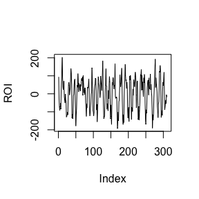

```r
ROI = ((dat[50, 32, 15,] - mean(dat[50,32,15,]) + dat[51, 32, 15,] - mean(dat[51,32,15,]) +
      dat[52, 32, 15,] - mean(dat[52,32,15,]) + dat[53, 32, 15,] - mean(dat[53,32,15,])) /4)

plot(ROI, type = "l")
```

With this data, we can have the following datamatrix, which shall be called boxtimings. For the first timing, we will have the following designmatrix.

```r
boxtimings <- designmatrix(ROI = ROI, timings = time[, 1], nbox = 5, lenbox = 4, TR = 2)
boxtimings$timing1
```

```
##        [,1] [,2] [,3] [,4] [,5] [,6] [,7] [,8] [,9] [,10]
##   [1,]    0    0    0    0    0    0    0    0    0     0
##   [2,]    0    0    0    0    0    0    0    0    0     0
##   [3,]    0    0    0    0    0    0    0    0    0     0
##   [4,]    0    0    0    0    0    0    0    0    0     0
##   [5,]    0    0    0    0    0    0    0    0    0     0
##   [6,]    0    0    0    0    0    0    0    0    0     0
##   [7,]    0    0    0    0    0    0    0    0    0     0
##   [8,]    0    0    0    0    0    0    0    0    0     0
##   [9,]    0    0    0    0    0    0    0    0    0     0
##  [10,]    0    0    0    0    0    0    0    0    0     0
##  [11,]    1    0    0    0    0    0    0    0    0     0
##  [12,]    1    0    0    0    0    0    0    0    0     0
##  [13,]    0    1    0    0    0    0    0    0    0     0
##  [14,]    0    1    0    0    0    0    0    0    0     0
```

[output cut: 296 more lines]

Finally, we want to use those boxtimings to calculte the maximum beta-value of every HRF.

```r
nbox = 5
lenbox = 4
fbrbetafunc(dat, boxtimings, ROI, timings = time[,1], nbox, lenbox, TR = 2, maximum = T )
```

```
##            [,1]
##  [1,] 146.75464
##  [2,] 113.48340
##  [3,]  62.60718
##  [4,]  86.01172
##  [5,]  84.99573
##  [6,]  46.04004
##  [7,]  70.33166
##  [8,]  66.46326
##  [9,] 100.19324
## [10,]  97.90906
## [11,]  88.33496
## [12,] 116.97913
## [13,] 121.57288
## [14,]  90.30762
## [15,] 108.10266
## [16,] 104.85059
## [17,]  85.01379
## [18,]  86.12671
## [19,] 115.74524
## [20,] 139.31470
```

It is also possible to estimate the BOLD with the FBR. For a more accurate estimation, we will use 20 boxes, with length 1. So, we need a total of 20 designmatrix (for every timing one).

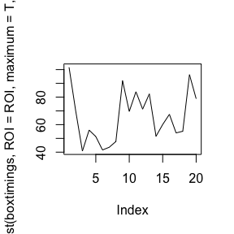

```r
nbox = 20
lenbox = 1
boxtimings <- designmatrix(ROI = ROI, timings = time[, 1], nbox = nbox, lenbox = lenbox, TR = 2)
plot(main.interest(boxtimings, ROI = ROI, maximum = T, nbox = nbox), type = "l")
```

To fully understand the model, it is possible to show every maximum beta-value for every designmatrix.

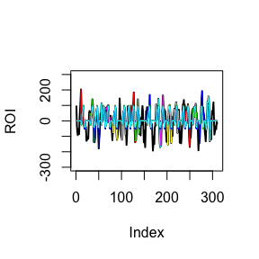

```r
plot(ROI, type = "l", lwd = 2, ylim = c(-300, 300))
for (i in 1:length(boxtimings)) {
  lines(boxtimings[[i]] %*% betafunc(boxtimings[[i]], ROI),col=(i+1))
}
```

# Advanced: Connectivity

Functional connectivity is a measurement of how two brain areas/regions correlated with each other. This package can also be used to do this. To do a connectivity analysis, we need to correlate the beta-series of two region.

For example, We have the following demeaned temporal areas,

```r
ROI1 = ((dat[50, 32, 15, ] - mean(dat[50, 32, 15, ]) + dat[51, 32, 15, ] -
    mean(dat[51, 32, 15,]) + dat[52, 32, 15,] - mean(dat[52, 32, 15,]) +
    dat[53, 32, 15,] - mean(dat[53,32,15,])) / 4)
ROI2 = ((dat[17,32,14,] - mean(dat[17,32,14,]) + dat[17,33,14,] -
    mean(dat[17,33,14,]) + dat[17,34,14,] - mean(dat[17,34,14,]) + dat[17,35,14,] -
    mean(dat[17,35,14,])+ dat[17,32,13,] - mean(dat[17,32,13,]) + dat[17,33,13,]
    - mean(dat[17,33,13,]) + dat[17,34,13,] - mean(dat[17,34,13,]) + dat[17,35,13,]
    - mean(dat[17,35,13,])) / 8)
```

which is visually presented as,

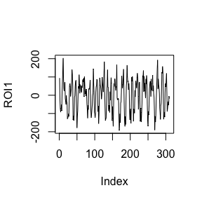

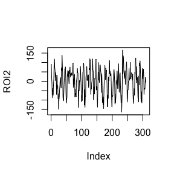

```r
plot(ROI1, type = "l")
plot(ROI2, type = "l")
```

Since the FBR is a flexible method, we chose to have 2 boxes, of length 10. The data (the “filtered_func_data.nii”-file) and the timings are the same, so no adaptation is required.

```r
nbox = 2
lenbox = 10

boxtimings1 <- designmatrix(ROI = ROI1, timings = time[, 1], nbox = nbox,
                            lenbox = lenbox, TR = 2)
boxtimings2 <- designmatrix(ROI = ROI2, timings = time[, 1], nbox = nbox,
                            lenbox = lenbox, TR = 2)

cor(main.interest(boxtimings1, ROI = ROI1, maximum = T, nbox = nbox),
    main.interest(boxtimings2, ROI = ROI2, maximum = T, nbox = nbox))
```

```
##           [,1]
## [1,] 0.8776699
```

So, we have a correlation of .88 between these 2 regions.

# The general function

In previous 2 sections, we analysed the data step by step. However, this package includes a general function, which is the combination of the previous steps. We will elaborate on this general function with one argument per line.

```r
region1 <- fbrbetafunc(dat = readData("filtered_func_data.nii"),
            ROI = ((dat[50, 32, 15, ] - mean(dat[50, 32, 15, ]) + dat[51, 32, 15, ] -
              mean(dat[51, 32, 15,]) + dat[52, 32, 15,] - mean(dat[52, 32, 15,]) +
              dat[53, 32, 15,] - mean(dat[53,32,15,])) / 4),
            boxtimings = designmatrix(ROI = ROI1, timings = time[, 1], nbox = 5,
                        lenbox = 4, TR = 2),
            timings = time[,1],
            nbox = 5,
            lenbox = 4,
            TR = 2,
            maximum = T)
beta1 <- main.interest(region1, ROI = ROI,  maximum  = T, nbox = 5)

region2 <- fbrbetafunc(dat = readData("filtered_func_data.nii"),
             ROI = ((dat[17, 32, 14, ] - mean(dat[17, 32, 14, ]) + dat[17, 33, 14, ] -
               mean(dat[17, 33, 14,  ]) + dat[17, 34, 14, ] - mean(dat[17, 34, 14, ]) + dat[17, 35, 14, ] -
               mean(dat[17, 35, 14,  ]) + dat[17, 32, 13, ] - mean(dat[17, 32, 13, ]) + dat[17, 33, 13, ]
               - mean(dat[17, 33, 13, ]) + dat[17, 34, 13, ] - mean(dat[17, 34, 13, ]) + dat[17, 35, 13, ]
               - mean(dat[17, 35, 13, ])) / 8),
             boxtimings = designmatrix(ROI = ROI2, timings = time[, 1], nbox = 5,
                lenbox = 4, TR = 2),
             timings = time[,1],
             nbox = 5,
             lenbox = 4,
             TR = 2,
             maximum = T)
beta2 <- main.interest(region2, ROI = ROI2,  maximum  = T, nbox = 5)

cor(beta1, beta2)
```

```
##           [,1]
## [1,] 0.6709698
```